# Writing Reports in Quarto using RStudio

# 10 Adding external figures

You can easily include images and figures that are **stored outside your Quarto document** — such as `.png`, `.jpg`, `.svg`, or `.pdf` files.

## 10.1 Basic Markdown image syntax

The simplest way to add an image is with standard Markdown:

```markdown
![Caption describing the image](images/plot1.png)
```

- `![ ]` — contains the figure caption
- `( )` — contains the file path
- If your image is in the same folder as your `.qmd` file, you can just use the file name (e.g. `figure1.png`).
- You can also add images with URLs, but this is poor practice RE reproducibility
- If you do this, you’ll have to add `embed-resources: true` in your YAML header to ensure everything is packaged in a single place.

```markdown
![Happiest dog in the world](https://a-z-animals.com/media/2021/04/happy-golden-retriever-3-1024x819.jpg)
```

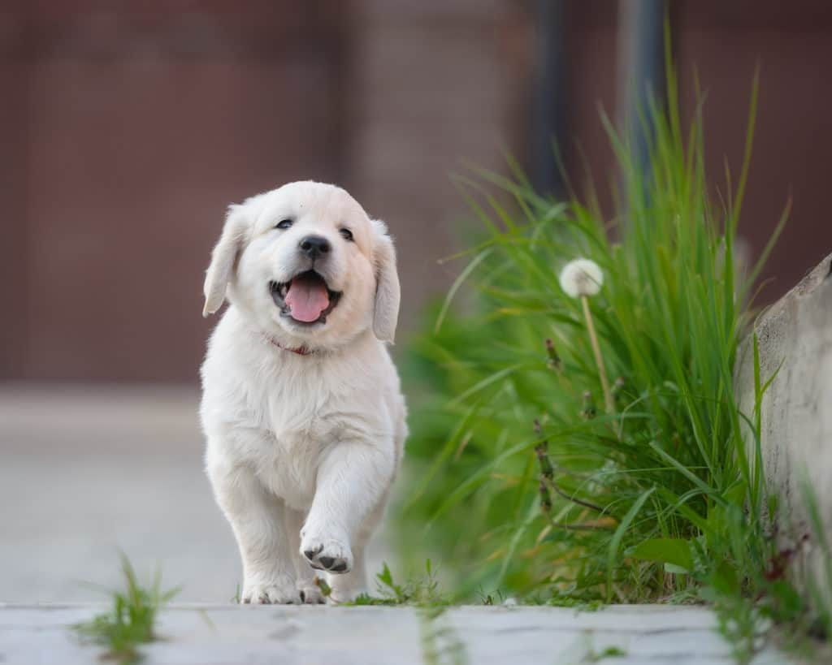

Happiest dog in the world

## 10.2 Supported image formats

| Format | Description | Notes |
| --- | --- | --- |
| `.png` | Portable Network Graphics | Good for raster plots (ggplot, base R) |
| `.jpg` | JPEG | Compressed, smaller files, less crisp |
| `.svg` | Scalable Vector Graphics | Perfect for line art and vector graphics |
| `.pdf` | Portable Document Format | High quality, ideal for publication figures |

## 10.3 Controlling figure layout in reports

You can arrange multiple images side-by-side using Pandoc’s **columns** syntax:

```markdown
::::{.columns}
::: column
![](images/fig1.png){fig-cap="Figure A" width=100%}
:::
::: column
![](images/fig2.png){fig-cap="Figure B" width=100%}
:::
::::
```

💡 This creates a two-column layout — useful for comparing plots or panels.

## 10.4 Recommended workflow

1. Create an `/images` folder in your project directory
2. Save or export all figures to this folder
3. Reference them in your `.qmd` file with relative paths:

   ```markdown
   ![](images/my_figure.png){fig-cap="My figure caption"}
   ```

4. Keep filenames short and descriptive (e.g. `plot_speed_dist.png`)

# 11 Adding tables

Tables in Quarto can be created in two main ways:  
1. **Manually**, using Markdown syntax  
2. **Automatically**, using R code outputs

## 11.1 Basic Markdown tables

You can write tables directly in Markdown using `|` and `-` characters to define columns and headers.

```markdown
| Species | Mass (g) | Wingspan (cm) |
|----------|-----------|---------------|
| Sparrow  | 24        | 21            |
| Starling | 78        | 34            |
| Crow     | 320       | 84            |
```

**Rendered output:**

| Species | Mass (g) | Wingspan (cm) |
| --- | --- | --- |
| Sparrow | 24 | 21 |
| Starling | 78 | 34 |
| Crow | 320 | 84 |

💡 Tip: You can align text by adding `:` —  
`:---` (left), `:---:` (center), `---:` (right).

## 11.2 Creating tables with R code

Quarto supports several R packages that produce attractive, formatted tables in your reports.  
These tables update automatically whenever you re-render your document.

## 11.3 Using `knitr::kable()`

The simplest way to make a polished table is with **`knitr::kable()`**.

```r
library(knitr)
kable(head(cars), caption = "First six rows of the cars dataset")
```

| speed | dist |
| --- | --- |
| 4 | 2 |
| 4 | 10 |
| 7 | 4 |
| 7 | 22 |
| 8 | 16 |
| 9 | 10 |

**Rendered output:**  
A clean, lightweight table — perfect for HTML or PDF reports.

## 11.4 Using `gt` for professional-quality tables

The **`gt`** package gives you full control over table styling, alignment, and formatting.

```r
library(gt)
cars %>%
  head(10) %>%
  gt() %>%
  tab_header(
    title = "Speed and Stopping Distance",
    subtitle = "Sample from the cars dataset"
  ) %>%
  fmt_number(columns = c(speed, dist), decimals = 1)
```

Formatted table using gt

Speed and Stopping Distance

Sample from the cars dataset

| speed | dist |
| --- | --- |
| 4.0 | 2.0 |
| 4.0 | 10.0 |
| 7.0 | 4.0 |
| 7.0 | 22.0 |
| 8.0 | 16.0 |
| 9.0 | 10.0 |
| 10.0 | 18.0 |
| 10.0 | 26.0 |
| 10.0 | 34.0 |
| 11.0 | 17.0 |

💡 `gt` automatically applies nice fonts, spacing, and captions.  
It’s the best option for HTML output.

## 11.5 Using `flextable` (great for Word documents)

If your students will render reports to Word (`.docx`), `flextable` produces tables that remain editable in Word.

```r
library(flextable)
flextable(head(cars))
```

Flextable example

| speed | dist |
| --- | --- |
| 4 | 2 |
| 4 | 10 |
| 7 | 4 |
| 7 | 22 |
| 8 | 16 |
| 9 | 10 |

✅ Works beautifully in **Word** and **PDF** outputs.  
💡 Requires `officer` and `flextable` packages to be installed.

## 11.6 Styling and captions

- Use `#| tbl-cap:` in the chunk options to add a caption automatically
- You can also add a manual caption using the function argument (e.g. `caption = "..."` in `kable()`)
- Each table type supports cross-referencing with labels (e.g. `#tbl-cars`)

## 11.7 Summary

| Method | Best for | Appearance | Key function |
| --- | --- | --- | --- |
| `knitr::kable()` | Simple, fast | Clean default HTML/PDF | `kable()` |
| `gt` | Professional reports | Highly styled, customisable | `gt()` |
| `flextable` | Word documents | Editable and neat | `flextable()` |

# 12 Citing references

You can add a bibliography in your YAML header if you want…

**Markdown syntax:**

```markdown
---
title: "My Report"
bibliography: references.bib
---
```

Then cite in text with `@citationkey`, e.g.:

> Quarto supports citations just like R Markdown [@knuth1984].

Render your report:

```bash
quarto render myreport.qmd
```

This is quite involved, and probably not useful for your LIFE4138 coursework. If you want to use it another time and get stuck, let me know! 🤩

# 13 Rendering your report

## 13.1 In RStudio

- Click the **Render** button (top toolbar)
- Or run in console:

  ```r
  quarto::quarto_render("myreport.qmd")
  ```

## 13.2 Output options

**Markdown syntax:**

```markdown
format:
  html: default
  pdf: default
  docx: default
```

# 14 Customising appearance

You can style your document with:

- **Themes:** `theme: cosmo`, `theme: flatly`, `theme: journal`
- **Code highlighting:** `highlight-style: github`
- **TOC and section numbering:**

**Markdown syntax:**

```markdown
toc: true
number-sections: true
```

# 15 Common mistakes to avoid

- ❌ Missing or unbalanced `---` in YAML
- ❌ Using tabs instead of spaces in YAML
- ❌ Forgetting to close code chunks
- ❌ Using R Markdown syntax like `{r, echo=TRUE}` (no comma syntax in Quarto)

✅ Use Quarto-style chunk options with `#|`.

# 16 Summary

🎯 Quarto helps you:

- Write **reproducible, dynamic reports**
- Integrate **R code and outputs**
- Produce **professional documents** in any format
- Transition seamlessly from R Markdown

# 17 Useful resources

- 📘 [Quarto documentation](https://quarto.org)
- 💻 [RStudio Quarto guide](https://quarto.org/docs/get-started/hello/rstudio.html)
- 🧑‍🏫 [Markdown cheat sheet](https://www.markdownguide.org/cheat-sheet/)
- 🧠 [Reproducible reports tutorial (RStudio)](https://rstudio.com/resources/cheatsheets/)